# Class 1: Political Violence

Introduction and types of political violence

[Dr. Michael C. Zeller](https://michaelzeller.de)

# Poll: course introduction

[figure not shown]

Take the survey at **https://forms.gle/iXweLEsJ7VTANrmGA**

- Most significant cause of political violence?
- Any politically violent groups you are interested in studying?
- Have you taken any methods course?
- Are you familiar with any analytical software (e.g., R, Python, Stata, SPSS)?
- What is your biggest concern for this course?

# Course Introduction

- What is ‘political violence’?
- How this course relates to Prof. Bolleyer’s lecture
- Course structure
- Learning aims
- Notes of caution
- Course assessment
- Office hours and communication
- course website
- Q & A and student introductions

[Crazy German GIF](https://tenor.com/view/crazy-german-flag-germany-trikot-gif-12722037627503073743) from [Crazy GIFs](https://tenor.com/search/crazy-gifs)

## First…

**Can you understand me?**

- Lots of different languages represented in the room → but please don’t be shy: feel empowered to participate, even if you are not so confident in your English skills
  - when you speak, please speak up (*I’m rapidly ageing and my hearing is not what it once was*)

## First task…

Read the syllabus!

- We have a shiny new (developing) website for the course
  - https://michaelzeller.de/course-pv/
- Before our next meeting, your task is to peruse the website
  - especially the Syllabus and Readings pages.

## Defining political violence

- Broadly: *the use of force by a person or group with a political motivation/purpose*
- it includes (but is certainly not limited to) assault, robbery, rioting, insurgency, assassination, terrorism, rebellion, guerrilla warfare and civil war, revolution
- acts of political violence can be distinguished by *the nature of the objectives*, *the targets of attacks*, the *organisational structure* of groups, and by the *repertoire of actions*.

## Connection to Prof. Bolleyer’s lecture

- This course is one of the Grundkurse for Prof. Bolleyer’s **Einführung in das politische System Deutschlands**
- This course is a detailed investigation of a related topic—not a tutorial on the material in Prof. Bolleyer’s lecture
  - So—as should go without saying—for both the lecture and GK: read and attend classes

## Structure of the course

| Date | Class | Lecture |
| --- | --- | --- |
| 2026-10-12 | 1 | Introduction and types of political violence |
| 2026-10-19 | 2 | Causes: setting the stage for political violence |
| 2026-10-26 | 3 | Radicalisation |
| 2026-11-02 | 4 | Selecting violent/nonviolent strategies |
| 2026-11-09 | 5 | Radical subcultures and mobilisation |
| 2026-11-16 | 6 | Leadership |
| 2026-11-23 | 7 | Foreign fighters |
| 2026-11-30 | 8 | Election-related violence |
| 2026-12-07 | 9 | Escalation and restraint |
| 2026-12-14 | 10 | Local support and public reaction |
| 2026-12-21 | 11 | State responses: policies |
| 2027-01-11 | 12 | State responses: repression |
| 2027-01-18 | 13 | Addressing violence online |
| 2027-01-25 | 14 | Disengagement, deradicalisation (individual), demobilisation (organisational) |
| 2027-02-01 | 15 | NO CLASS MEETING TODAY |

## Narrowing the field

- there’s a lot of political violence around…
- In this course, we will focus on
  - non-state
  - organised groups
  - in Germany and other (liberal) democratic contexts (with some exceptions)
- The course is arranged to cover a diverse array of cases within these parameters (we’ll discuss ‘assigned cases’ momentarily)

## Aims

- acquire **substantive knowledge** of aspects of political violence and manifestation within Germany and elsewhere
- enhance **critical knowledge** to evaluate research thereof
- gain familiarity with **methodological approaches** to studying political violence
- (further) develop the capacity to…
  - assess episodes and broader cycles of political violence, especially by identifying underlying factors and comparing across contexts
  - critically evaluate reporting, research, and policy on political violence, especially by evaluating the data and methods used

## Notes of caution

Accounts of political violence can be alarming, disturbing, horrifying… — so some ground rules are necessary

- graphic (i.e., vivid, shocking) images and even accounts will be avoided in course materials. Exceptions only in cases of necessity and with forewarning
- any sympathies (towards any contenders) should be restrained in favour of sober consideration of cases and topics
- normative considerations are not the focus of this course. It is *what, who, when, where, how, why* — not so much *should*
  - generally, the course materials do not challenge the legitimacy of the state’s **monopoly of violence**
- with concerns and questions, come talk with me

## Assessment: related to BRD lecture

| Studiengang | Belegung | Leistungsnachweis(e) | Klausurinhalte |
| --- | --- | --- | --- |
| BA Hauptfach | VL (Vorlesung BRD) und GK (Grundkurs) | Klausur (90 Min.) | 3/5 Wissensfragen und 1/3 Essayfrage |
| BA Nebenfach 60 ECTS | VL und GK | Klausur (90 Min.) | 3/5 Wissensfragen und 1/3 Essayfrage |
| Lehramt Unterrichtsfach | VL und GK | Klausur (90 Min.) & Referat | 3/5 Wissensfragen und 1/3 Essayfrage |
| BA Nebenfach 30 ECTS | nur VL | Klausur (90 Min.) | 3/5 Wissensfragen kein Essay |
| Lehramt Didaktikfach | nur VL | Klausur (60 Min.) | 2/5 Wissensfragen kein Essay |
| Austauschstudierende für VL | VL | Klausur (90 Min.) | 3/5 Wissensfragen kein Essay |
| Austauschstudierende für GK | GK | Festgelegt durch GK Dozent | N/A |

Die Sprache der Essayfragen (Deutsch oder Englisch) richtet sich nach der Sprache des jeweiligen GKs. Unabhängig von der Sprache der Fragestellung (oder Teil der Veranstaltung) können Studierende je nach Präferenz auf Deutsch oder Englisch antworten.

**Kontakt für prüfungsrechtliche Fragen, Kursanmeldung, - wechsel, - abmeldung, Fragen zur Anmeldung zur Prüfung: studienbuero@gsi.uni-muenchen.de**

## Assessment: within this course

|  | Participation | Presentation | Essay | Klausur |
| --- | --- | --- | --- | --- |
| BA Hauptfach | X |  |  | X |
| BA Nebenfach (60 ECTS) | X |  |  | X |
| Lehramt Unterrichtsfach | X | X |  | X |
| BA Nebenfach (30 ECTS) | X |  |  | X (nur VL) |
| Lehramt Didaktikfach | X |  |  | X (nur VL, 60 Min., 2 Wissensfragen) |
| Austauschstudierende für VL | X |  |  | X (nur VL) |
| Austauschstudierende für GK | X | X | X |  |

## Course assessment - *Participation*

- No examination in this course, BUT there is in ‘*Einführung Politisches System der BRD*’. There, you respond to an essay question from this course.
  - Exam on 1 February (Monday) at 14.00 in the [AudiMax](https://www.lmu.de/raumfinder/#/building/bw0000/map?room=000000100_)
  - 90-minutes written exam: response to 3 of 5 short-answer prompts from Prof. Bolleyer’s lecture and to 1 of 3 essay prompts from this course
  - can bring a translation dictionary (e.g., German-Ukrainian)
    - be certain it has no notes inside!
  - Exam registration in December—careful not to miss it
- read, develop knowledge of assigned politically violent group, attend class and actively participate

## Course assessment - *Presentation*

- **Presentation**
  - short (max. 20 minutes) group (2-4 students) talk on a method for studying political violence
  - A *method* is a system of data collection and analysis
    1. introduce method,
    2. explain its utility for studying political violence,
    3. [the crucial part] and *discuss one applied example*
- recipe for success: search for a journal article on a topic of interest to you and select your *method* on that basis

## Essay (*Hausarbeit*): Data report

- data report on a political violence phenomenon (e.g., attacks, organisational membership)
  - why a dataset? Helpful preparation for thinking about validity, reliability, etc. → relevant for quant. and qual.
- gather and present data, generate analytical insights
- 2000-3000 words (excluding citations)
- 2027-01-15: short synopsis due. 2027-03-05: full, final report due.
- consider working with data visualisation and analysis software
  - but not required! Students have aced essay with Excel/Word
- A rule: **no data from or use of Statista or data curation services**.

**submit all assignments by email: m.zeller@lmu.de**

## For the paper, and writing in general…

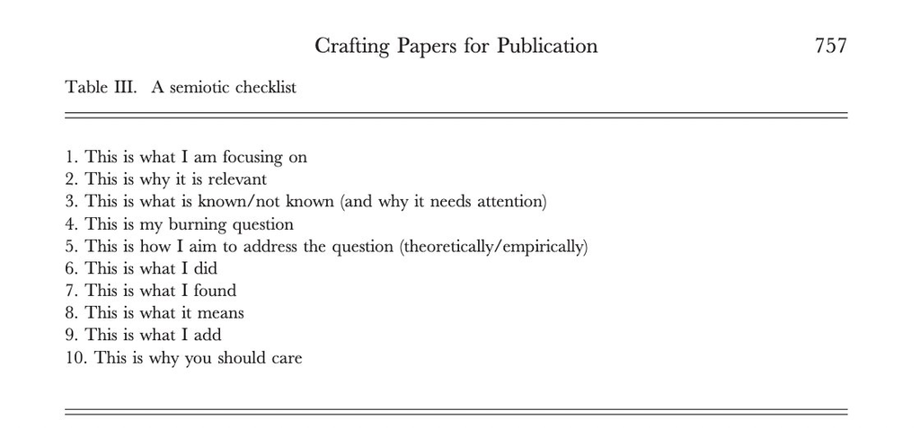

Patriotta, G. (2017). Crafting papers for publication: Novelty and convention in academic writing. *Journal of Management Studies, 54*(5), 747-759.

## Further: tools of the research trade…

- qualitative data management: e.g., MAXQDA, ATLAS.ti
- quantitative (and qual.) data analysis software: e.g., R (and R Studio), Stata
- typesetting programmes: LaTeX (through [TexStudio](https://www.texstudio.org/)) and RMarkdown

## Elements of a typical class meeting

- Opening question(s)/discussion point(s)
  - e.g., theoretical dilemma, typology forming, news item
- Summarising lecture on theory/findings related to week’s topic
- A live poll: general questions and about your group
  - questions about groups shown on last slide of preceding week
- Short video relevant to topic
- Discussing the reading(s), highlighting important points
- Student presentation(s)
- Open data for you to explore
- Summative discussion: takeaways, new ideas, lingering questions

Throughout, we will use *cases* to link *theory* to *real-world events*

## Cases for students

- to be assigned in Week 2

[figure not shown]

[figure not shown]

[figure not shown]

[figure not shown]

[figure not shown]

[figure not shown]

[figure not shown]

## Open data - on slides coloured like this

- data from published research and ongoing projects
  - available for download (in slides or from external website)
- interactive visualisations
  - scalable line/bar plots
  - network graphs
  - maps
- a chance to explore data related to a topic
  - recognised patterns and *describe* the world of social movements
  - opportunity to go further, if it interests you

## Blessed with too much material

- most classes are overfull with videos, research snapshots, poll questions, etc.
  - this is a *seminar*
    - *discussion* is the priority
  - makes it even more important to do required reading, review any slides that we cannot cover in class
- in extreme case (lots of material uncovered) I will upload a video to the course website

## Classroom air quality

- in an earlier term, a student with respiratory issues took CO2 readings in classes with closed and then slightly open window…

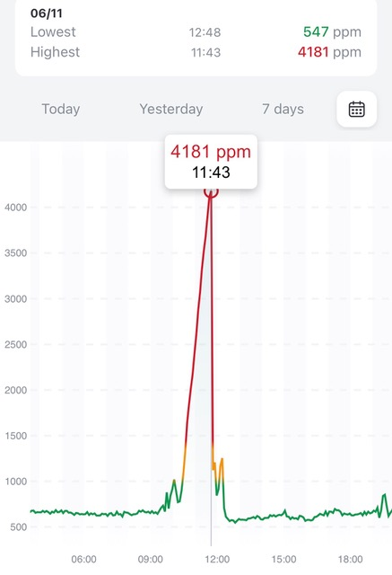

closed window

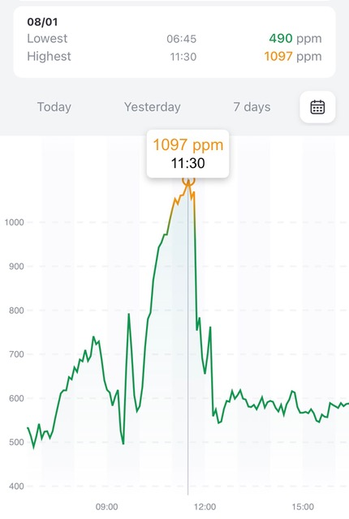

slightly open window

since [lower indoor C02 improves cognition](https://doi.org/10.1111/ina.12706)… we will air before class and (unless it is way too cold) at least tilt a window during class

## In case class cannot meet…

- If it is not possible to convene in-person,
  - you will receive an email:
  1. the class will meet online via Zoom (link in email), or
  2. the class will be cancelled, a recorded lecture uploaded on the ‘Slides’ page of the website, and a short review at the start of the next meeting
     - 7 December (Class 9) will be cancelled and replaced with a video lecture

## Colour scheme for course slides

- Why? To make concepts and important points easier to identify and review
- concepts (dark red) - building blocks of social science, important elements in every class session
- discussion point (indigo) - a question or prompt to discuss as a class (essential component of a *seminar*)
- finding (dark orange) - a noteworthy finding from one or more studies
- methods point (blue) - element of research design or methodology
- important point (red) - something particularly noteworthy
- *other colours* - variously trying to get your attention

## Office hours and communication

- best to send an email
  - michael.zeller@gsi.uni-muenchen.de
  - m.zeller@lmu.de
- 11.00 - 12.00 on Wednesdays at GSI (Oettingenstr. 67) - Room H105
- or by appointment
- Please use your LMU email address for communication
  - this is important for the security of the university email system

## Course website

- no use of Moodle
- a purpose-built website: https://michaelzeller.de/course-pv/
  - all readings available
  - slides available before class
    - PDF copies may omit some parts of HTML slides (e.g., animations, data visualisations)—but those HTML copies will always be available for you too
  - (if necessary) video lectures
  - example data report
  - some resources

## Resources

- The **Armed Conflict Location & Event Data Project (ACLED)** collects real-time data on political violence and protest events around the world: https://acleddata.com/.
- **Uppsala Conflict Data Program (UCDP)**: https://ucdp.uu.se/.
- ECPR [Standing Group on Political Violence](https://ecpr.eu/StandingGroups/StandingGroupHome.aspx?ID=45)
- **Journals**:
  - [Terrorism and Political Violence](https://www.tandfonline.com/loi/ftpv20?cookieSet=1)
  - [Studies in Conflict & Terrorism](https://www.tandfonline.com/toc/uter20/current)
  - [Perspectives on Terrorism](https://www.jstor.org/journal/persponterr)
  - [Journal for Deradicalization](https://journals.sfu.ca/jd/index.php/jd/index)
  - [International Journal of Conflict and Violence](https://www.ijcv.org/index.php/ijcv/about)

## About me

- tell me if you have problems understanding me
  - there’s an accent at work that I tragically cannot shake off
- Ph.D. in political science from Central European University (CEU)
  - specialisation in qualitative methods (QCA, [Bayesian] process tracing), but also quant. text analysis, network analysis
- researcher in funded projects on …
  - violent/banned far-right groups and online content moderation
  - radicalisation, violent extremism, polarisation, and resilience
- current work: militant democracy; far-right activist networks; political violence (in 1970s Northern Ireland; in contemporary Italy); paths to female leadership in Asia; protest and polarisation

## About the course

**Q & A**

[interactive chart not shown]

Prior methods class

[interactive chart not shown]

Prior analytical software use

[interactive chart not shown]

## About you! Poll results

Most significant cause of political violence?

[interactive chart not shown]

## About you! Poll results

Any particular politically violent group you want to learn more about?

[interactive chart not shown]

## About you! Student introductions

- Information about you, possibly including…
  - Expectations for this course
  - favourite joke
  - Study programme
  - favourite song
  - Country (place) of origin
  - top source for news
  - Background in education/research
  - secret skill
  - Academic/professional aspirations

## About you! Poll results: biggest concern

[interactive chart not shown]

# Quick intro to concepts

- concept formation (cf. Adcock and Collier 2001)
- types of concepts

[What A Concept Smile GIF](https://tenor.com/view/what-a-concept-smile-asking-happy-gif-15962654)from [What A Concept GIFs](https://tenor.com/search/what+a+concept-gifs)

## Concept formation

- **concepts** are the building blocks of social science research
  - a term denoting an abstract idea

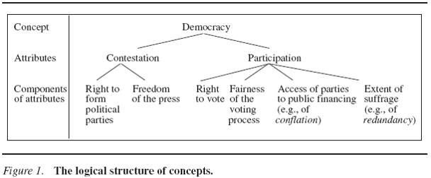

## Concept formation

- identifying bounds of concepts
  - See Sartori (1970)
- broadly, three types of concepts in social science
1. classical: **all** criteria are shared by **all** cases
2. radial: **some** criteria are shared by **all** cases; others are not
3. family resemblance: **No** criterion is shared by **all** cases

## Visualising classical/radial concepts

Classical concept (all criteria)

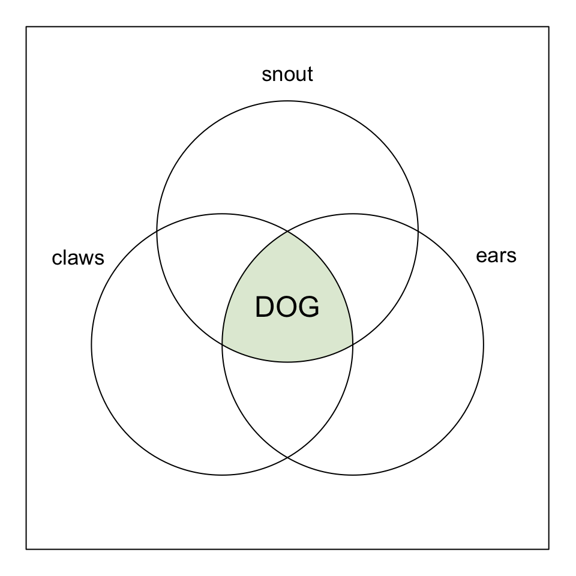

Radial concept (all share ‘female’)

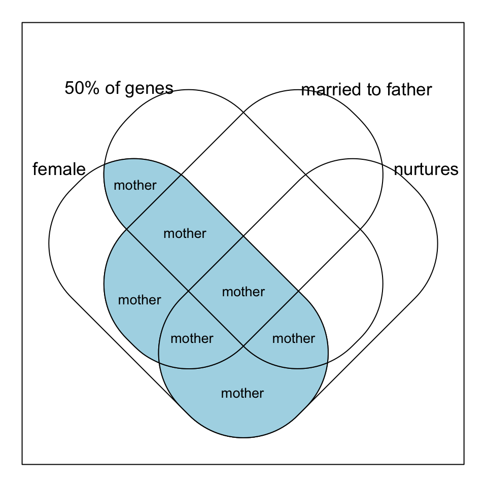

Family resemblance: no criterion shared by all (e.g., games)

## Classical vs. radial (Collier and Mahon 1993)

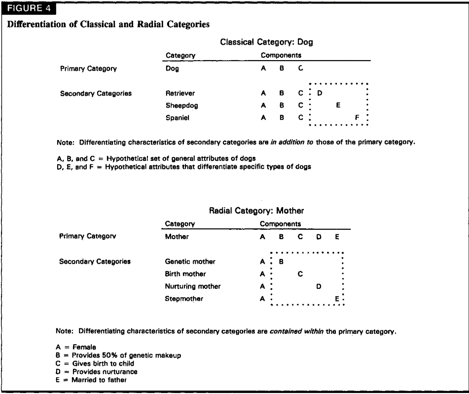

# Onto our topic: political violence (PV)

- ‘patterns of violence’ framework
  - repertoires, targeting, frequency, techniques
- Ravndal (2015) RW terrorism in western Europe
  - dimensions as a heuristic for understanding politically violent groups, generally?

[Dont Get Aggressive Violence GIF](https://tenor.com/view/dont-get-aggressive-violence-violin-3d-gifs-artist-violence-is-not-the-answer-gif-17884347)from [Dont Get Aggressive GIFs](https://tenor.com/search/dont+get+aggressive-gifs)

## Patterns of Violence

borrowing a conceptual framework from armed conflict research (Gutiérrez-Sanín and Wood 2017)

> a pattern of violence on the part of an armed organization (state force, rebel group, or militia) as the *relatively stable and recognizable configuration of violence in which it engages. This configuration consists of …*

## Patterns of Violence

borrowing a conceptual framework from armed conflict research (Gutiérrez-Sanín and Wood 2017)

repertoire

targeting

frequency

technique

## Patterns of Violence

borrowing a conceptual framework from armed conflict research (Gutiérrez-Sanín and Wood 2017)

targeting

frequency

technique

repertoire

- what forms of violence are used
  - beatings, stabbings, sexual violence, homicide, etc.

## Patterns of Violence

borrowing a conceptual framework from armed conflict research (Gutiérrez-Sanín and Wood 2017)

repertoire

targeting

frequency

technique

## Patterns of Violence

borrowing a conceptual framework from armed conflict research (Gutiérrez-Sanín and Wood 2017)

repertoire

frequency

technique

targeting

- the social groups against whom actors regularly use violent repertoires
  - an ethnic group, political opponents, LBGTI persons, militants of rival organisations, residents of certain areas, etc.

## Patterns of Violence

borrowing a conceptual framework from armed conflict research (Gutiérrez-Sanín and Wood 2017)

repertoire

targeting

frequency

technique

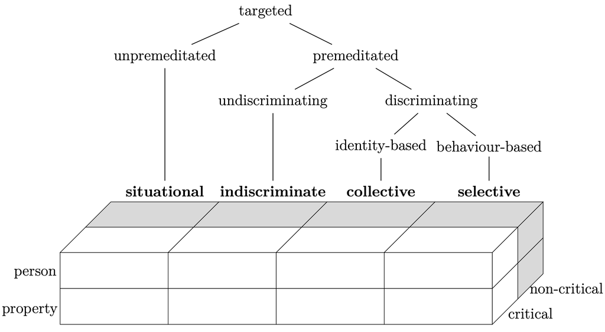

*targeting taxonomy (and related conceptual space)* (Zeller and Noschese 2025)

## Patterns of Violence

borrowing a conceptual framework from armed conflict research (Gutiérrez-Sanín and Wood 2017)

repertoire

targeting

frequency

technique

## Patterns of Violence

borrowing a conceptual framework from armed conflict research (Gutiérrez-Sanín and Wood 2017)

repertoire

targeting

technique

frequency

- count: number of attacks deploying a repertoire against a target
- rates (common in criminology research as well):
  - incidence: incidents per member of some referent population
  - prevalence: fraction of population that suffered an incident
  - perpetration: number of incidents or persons of the targeted group per member of the group of violent attackers

## Patterns of Violence

borrowing a conceptual framework from armed conflict research (Gutiérrez-Sanín and Wood 2017)

repertoire

targeting

frequency

technique

## Patterns of Violence

borrowing a conceptual framework from armed conflict research (Gutiérrez-Sanín and Wood 2017)

repertoire

targeting

frequency

technique

- how the actor(s) carry out their violence
- techniques are about the tools or instruments used (e.g., clubs, knives, guns, bombs)

## Patterns of Violence

repertoire

- what forms of violence are used
  - beatings, stabbings, sexual violence, homicide, etc.

targeting

- the social groups against whom actors regularly use violent repertoires
  - an ethnic group, political opponents, LBGTI persons, etc

frequency

- count: number of attacks deploying a repertoire against a target
- incidence rates, prevalence rates, perpetration rates

technique

- how the actor(s) carry out their violence
- techniques are about the tools or instruments used (e.g., clubs, knives, guns, bombs)

## Ravndal (2015) Europe RW terrorism

|  | Elite-sponsored groups | Subcultural networks | Lone actors |
| --- | --- | --- | --- |
| Organisational structure | Hierarchy |  | N/A |
| Leadership |  | Decentralized | N/A |
| Group membership | >100 | <50 | N/A |
| Known political strategy | Always | Sometimes | Sometimes |
| Affiliation to former right-wing regime | Yes | No | No |
| Sponsorship | Elites | Subculture | None |
| Significant access to military resources | Yes | No | No |
| International terrorism | Yes | No | No |

These are variables and types with which to consider politically violent groups — **Thoughts? Can we apply this generally or is it specific to RW? Any omissions?**

## Examples of political violence?

**What cases are you familiar with?**

**What do you know about them?**

**How can we categorise them?**

# Any questions, concerns, feedback for this class?

Anonymous feedback here: https://forms.gle/NfF1pCfYMbkAT3WP6

Alternatively, please send me an email: m.zeller@lmu.de

## References

Adcock, Robert, and David Collier. 2001. “Measurement Validity: A Shared Standard for Qualitative and Quantitative Research.” *American Political Science Review* 95 (3): 529–46. https://doi.org/10.1017/S0003055401003100.

Collier, David, and James E. Mahon. 1993. “Conceptual ‘Stretching’ Revisited: Adapting Categories in Comparative Analysis.” *American Political Science Review* 87 (4): 845–55. https://doi.org/10.2307/2938818.

Gutiérrez-Sanín, Francisco, and Elisabeth Jean Wood. 2017. “What Should We Mean by ‘Pattern of Political Violence’? Repertoire, Targeting, Frequency, and Technique.” *Perspectives on Politics* 15 (1): 20–41. https://doi.org/10.1017/S1537592716004114.

Ravndal, Jacob Aasland. 2015. “Thugs or Terrorists? A Typology of Right-Wing Terrorism and Violence in Western Europe.” *Journal for Deradicalization* 15 (3): 1–38.

Sartori, Giovanni. 1970. “Concept Misformation in Comparative Politics.” *The American Political Science Review* 64 (4): 1033–53.

Zeller, Michael C, and Pasquale Noschese. 2025. “Targeting Taxonomy and Patterns of Political Violence in Stable Societies: Evidence from the Far Right in Italy.” *Terrorism and Political Violence* 0 (0): 1–20. https://doi.org/10.1080/09546553.2025.2528059.